# RMarkdown Homework

MBIO 612 Week 6

Savannah Damiano

2024-10-05

# Homework Directions

1. Use any data sheet from class.
2. Create *at least* **one table** and **one figure** in an *RMarkdown* file.
3. Create a RMarkdown **output** as either an html, github doc, or pdf.
4. **Knit the file**.
5. Use headings with *clear* explanations of what you are doing.
6. Practice with **bold**, *italics*, and lists.
7. Make sure your **outputs and scripts** are saved in the appropriate folders.
8. Homework needs to be *pub quality* and make sure to *comment* on code!

# Load Libraries

```r
library(tidyverse)
library(here)
library(gtExtras)   #library to make table
library(PNWColors)  #library for plot colors
```

# Load Data

##### Data from Becker and Silbiger (2020)

```r
# Environmental data from each site (long data)
# Pull the data from our repository
EnviroData<-read_csv(here("Week_05","Data", "site.characteristics.data.csv"))
```

# Inspect Data

```r
glimpse(EnviroData)        #view the data in two ways
```

```
## Rows: 78
## Columns: 5
## $ name               <chr> "Anemone Heaven", "Hilton High", "Public Beach", "M…
## $ site.letter        <chr> "F", "C", "B", "E", "D", "A", "F", "C", "B", "E", "…
## $ site.block         <dbl> 1, 2, 3, 1, 2, 3, 1, 2, 3, 1, 2, 3, 1, 2, 3, 1, 2, …
## $ parameter.measured <chr> "light", "light", "light", "light", "light", "light…
## $ values             <dbl> 1674.241, 1193.230, 2647.890, 1533.245, 2114.013, 2…
```

```r
view(EnviroData)
```

# Modify Data

Goal:

1. To convert data to wide format
2. To visualize the *percent cover* across **six study sites** at varying *light* intensity

```r
EnviroData_wide <- EnviroData %>%
  pivot_wider(names_from = parameter.measured,
              values_from =values) %>%
  select(name, light, CCA.cover, algal.cover,coral.cover, substrate.cover)
# I pivot_wider so that it is easier for me to visualize the variables I wanted to select and their values
# When pivot_wider make sure you use the exact names from the original data frame
```

# Create a Table

Goal: To make a table to represent the *percent cover* and *total light* across the **six sites**

Table Specifics:

- I used the gt() package.
- I gathered information about the package through the following websites:

  -[How to Make Beautiful Tables in R](https://rfortherestofus.com/2019/11/how-to-make-beautiful-tables-in-r/) and [Introduction to Creating gt Tables](https://gt.rstudio.com/articles/gt.html)

```r
Table_1 <- EnviroData_wide %>%
  gt() %>%   #the type of table
  gt_theme_pff() %>%  # the theme I chose
  tab_header(title = "Cover Types and Total Light Across Six Study Sites" ) %>%
          # the name of the table
  cols_label(
    name = md("Site"),
    CCA.cover = md("CCA Cover (%)"),
    algal.cover = md("Algae Cover (%)"),
    coral.cover = md("Coral Cover (%)"),
    substrate.cover= md("Substrate Cover (%)")) %>% # renamed the columns
  opt_stylize(color = "pink")                       # add color(outline is pink)

gtsave(Table_1, filename = "HomeworkTable6B.html", path= "../Output/")

#named this figure 'Table_1' so that it could be saved in output folder
#used to gtsave to save table as an output
#saving the table to my output folder made the table disappear from my Rmarkdown. In office hours, Gabby helped me learn how to add it back.
#look at next R chunk for answer to the issue
```

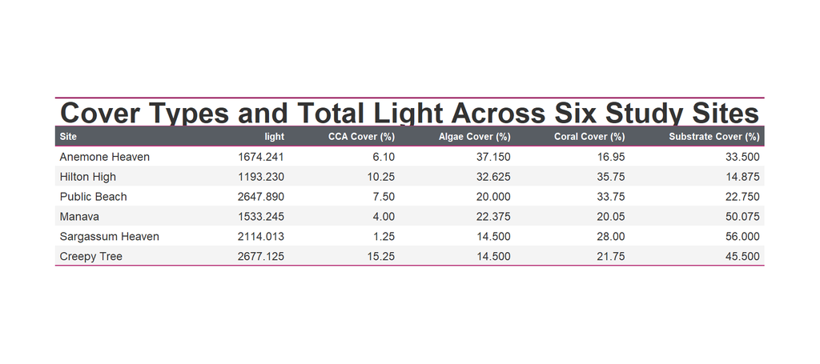

```r
plot(Table_1)
```

```r
#this r chunk called Table_1 to the markdown folder
# changed the width, height, and alignment so that it the whole graph would be visible in the Rmarkdown folder
```

# Modify Data

Goal: To convert data back to long format to make it easier to plot

```r
EnviroData_plot <- EnviroData_wide %>%
  pivot_longer(cols = CCA.cover:substrate.cover,
               names_to = "Cover_Type",
               values_to = "Percentage")
# in cols, make sure to use data frame names
# made new columns to make plotting easier
```

# Create a Bar Chart

Goal: To make a plot to represent the *percent cover* across the **six sites**

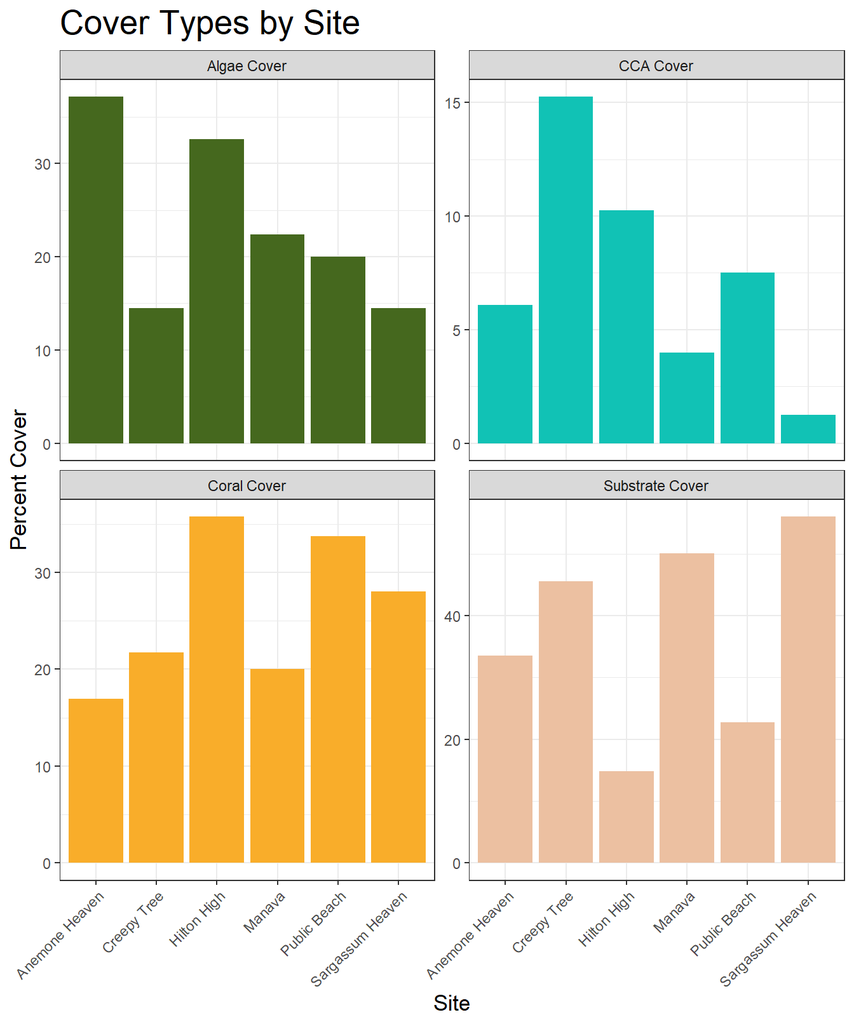

```r
  ggplot(EnviroData_plot, aes(x =name,             #name on x
                           y = Percentage,         #percent on y
                           fill = Cover_Type)) +   #cover type fills the bars
  geom_bar(stat = "identity", position = "dodge") +
  #stat = "identity" : use actual values provided in data
  #position = "dodge" : so the bars aren't stacked on top of each other
  labs(title = "Cover Types by Site",   #change the labels
        x = "Site",
        y = "Percent Cover") +
  theme_bw() +   #change theme
  theme(axis.text.x = element_text(angle = 45, hjust = 1)) +
          #adjust x axis titles so they do not overlap
  facet_wrap(~ Cover_Type,        #facet by cover type
             scales = "free_y",    # free_y allows each panel to have its own y-axis scale
             labeller = labeller(Cover_Type = c(`algal.cover` = "Algae Cover",
                                               `CCA.cover` = "CCA Cover",
                                               `coral.cover` = "Coral Cover",
                                               `substrate.cover` = "Substrate Cover"))) +
                                                #rename facet labels
  scale_fill_manual(values = c("#45681e", "#11c2b5", "#f9ad2a","#ecc0a1")) +
                              #manually color bar plot
  theme(plot.title = element_text(size = 20),     # enlarging the title font
        axis.title = element_text(size = 13),     # enlarge the axis font
        legend.position = "none")                 # remove legend
```